# Homework 5

Stat 452

Author

Anna

For this assignment, I want you to work on your own in your own file, generating ideas by yourself so that when you work with your partner, you’ll have twice the number of ideas.

## Data Context

1. Read the following two journal articles about the ACTIVE study.
- https://www.ncbi.nlm.nih.gov/pmc/articles/PMC3934012/
- https://www.ncbi.nlm.nih.gov/pmc/articles/PMC4055506/

Add the citations of these papers to the `Library.bib` file in the Github Repo by going to https://www.scholar.google.com and typing the article title. Find the article by double checking authors and titles. Click on Cite and then Bibtex and copy the @Article{key, …} text below into the `Library.bib` file.

2. Write a 5-10 sentence summary about this study and its study design. Cite the articles appropriately in this reflection using the following syntax `[@key]` (adjust `key` according to what you put in the `.bib` file). For example, I could write about misspecification of the covariance matrix in mixture models and refer to my paper (**heggeseth_impact_2013?**).

ANSWER: The Advanced Cognitive Training for Independent and Vital Elderly (ACTIVE) Study was a trial designed to test the effectiveness of cognitive interventions in memory, reasoning, and visual speed of processing. It received funding from the National Institute for Aging and the National Institute for Nursing Research (Tennstedt and Unverzagt 2013). As outlined by Rebok et al. (2014), the researchers contacted 5,000 individuals age 65 or older, of which 2,802 agreed and were accepted to participate. The study was a randomized, controlled clinical trial with four groups (three different cognitive intervention groups and one control group). All non-control participants received ten 60-75 minute training sessions, and a randomly selected subset also received booster sessions during the ten year long trial. Researchers assessed cognitive abilities after the intervention and at 1, 2, 3, 5, and 10 year intervals. Participants were assessed on a range of metrics from memory and recall tests to Instrumental Activities of Daily Living (IADL) functions (Rebok et al. 2014). According to Rebok et al. (2014), the training resulted in statistically significant cognitive improvements when compared with the control group: for memory training, the effects persisted at least five years; for reasoning and speed of processing, results persisted for ten years.

## Research Question

3. Develop a “linear regression” research question you’d like to explore about aging related to the clinical trial.

Outcome Ideas (choose 1): Reasoning, Memory, Speed of Processing, Functional Outcomes

Predictors: Treatment Group, Years, Baseline Age, Gender, Baseline Values [of any outcome], Interactions, Reasoning, Memory, Speed of Processing, Functional Outcomes

ANSWER: Among participants who received memory training, how does gender affect the relationship between years and memory?

4. Load in the ACTIVE study data and come up with two high quality graphs that provide insight about your research question.

ANSWER:

```r
source('cleaning_active.R') # Open Cleaning.R to see the data cleaning steps to create a long format dataset & more info about each variable
head(activeLong)
```

```
  AID                       INTGRP REPLCODE SITE BOOSTER GENDER AgeAtBaseline
1   1              Memory Training        5    1       1      1            76
2   2              Memory Training        2    1       1      2            67
3   3 Speed of Processing Training        6    6       1      2            67
4   4 Speed of Processing Training        4    3       1      2            78
5   5              Memory Training        3    5       1      2            72
6   6                      Control        2    4       0      2            69
  YRSEDUC DEATH_INDICAT DEATH_DUR time ADLT AVLTT  CRT1  CRT2 DAVOID DRIVER
1      12             0        NA    7   NA    NA    NA    NA     NA     NA
2      10             1      3506    7   NA    NA    NA    NA     NA     NA
3      13             0        NA    7    0    28 1.746 3.005      0      1
4      13             1      1706    7   NA    NA    NA    NA     NA     NA
5      16             0        NA    7    0    NA    NA    NA      0      1
6      12             0        NA    7    0    53 1.596 2.490     25      1
  DTOTP EPT HVLTT IMMRAW LSCOR LTCOR MMSE OTDL PTOTP      TIADL TOTDD TOTDS
1    NA  NA    NA     NA    NA    NA   NA   NA    NA         NA    NA    NA
2    NA  NA    NA     NA    NA    NA   NA   NA    NA         NA    NA    NA
3     0  21    17    2.5    10     6   28   27     0 -0.3942510 0.000     2
4    NA  NA    NA     NA    NA    NA   NA   NA    NA         NA    NA    NA
5     0  26    NA     NA    NA    NA   NA   NA     0         NA 4.167     2
6     0  22    29    6.5     9     6   27   20     0 -0.3218141 0.000     4
  UFOV1 UFOV2 UFOV3 UFOV4 WSCOR Years Age Memory Reasoning Speed
1    NA    NA    NA    NA    NA    10  86     NA        NA    NA
2    NA    NA    NA    NA    NA    10  77     NA        NA    NA
3    17    40   150   370     6    10  77   47.5        22   577
4    NA    NA    NA    NA    NA    10  88     NA        NA    NA
5    NA    NA    NA    NA    NA    10  82     NA        NA    NA
6    17   160   237   500    12    10  79   88.5        27   914
```

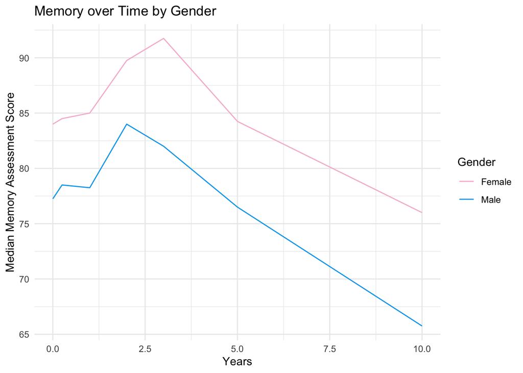

```r
activeLong <- activeLong |>
  mutate(
    gender = as.character(GENDER),
    gender = str_replace(gender, "1", "Male"),
    gender = str_replace(gender, "2", "Female"),
    booster = as.factor(BOOSTER)
    )

activeLong |>
  filter(INTGRP == "Memory Training") |>
  group_by(Years, gender) |>
  summarize(median = median(Memory, na.rm = TRUE)) |>
  ggplot(aes(x = Years, y = median, group = gender, color = gender)) +
  geom_line() +
  scale_color_manual(values = c("#F7B9D4", "#01A6EA")) +
  labs(
    y = "Median Memory Assessment Score",
    color = "Gender",
    title = "Memory over Time by Gender"
  ) +
  theme_minimal()
```

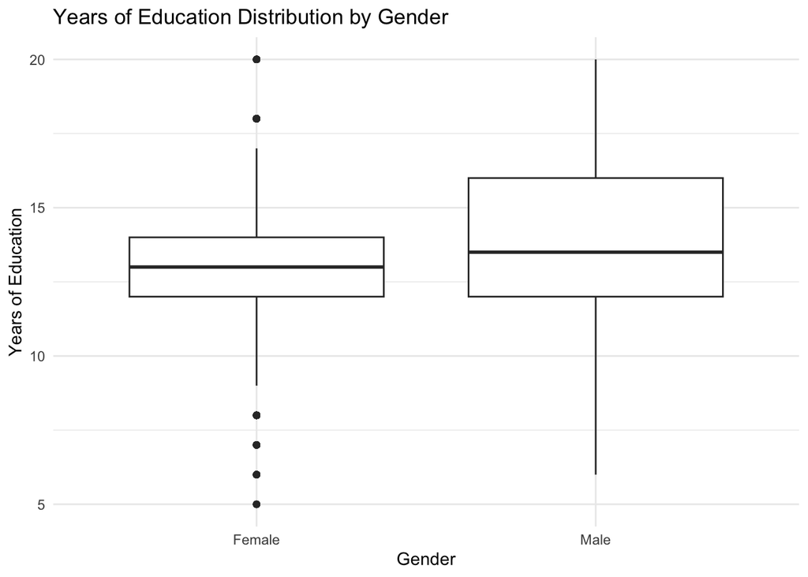

```r
activeLong |>
  filter(INTGRP == "Memory Training") |>
  ggplot(aes(x = gender, y = YRSEDUC)) +
  geom_boxplot() +
  labs(
    y = "Years of Education",
    x = "Gender",
    title = "Years of Education Distribution by Gender"
  ) +
  theme_minimal()
```

## Models

5. Use those graphs to inform fitting a series of linear models (using `lm`) predicting the outcome of your choice (as it relates to your research question). Make sure to consider interactions (whether the effect is the same within treatment groups). Provide code and output for one model that you feel is informative about your research question.

ANSWER:

```r
activeLongfltr <- activeLong |>
  filter(INTGRP == "Memory Training") |>
  mutate(years = as.factor(Years)) |>
  drop_na(Memory, years, gender, Age, YRSEDUC, BOOSTER)

mod1 <- lm(Memory ~ years + gender, data = activeLongfltr)

mod2 <- lm(Memory ~ Years*I(Years > 3)*gender, data = activeLongfltr)

mod3 <- geem(Memory ~ years*gender + Age + YRSEDUC + BOOSTER, data = activeLongfltr, id = AID, corstr = "ar1")

summary(mod1)
```

```
Call:
lm(formula = Memory ~ years + gender, data = activeLongfltr)

Residuals:
    Min      1Q  Median      3Q     Max
-75.353 -10.677   1.647  12.129  42.992

Coefficients:
            Estimate Std. Error t value Pr(>|t|)
(Intercept)  82.4863     0.7012 117.633  < 2e-16 ***
years0.25     0.8843     0.9622   0.919    0.358
years1        0.5213     1.0104   0.516    0.606
years2        5.1903     1.0225   5.076 4.07e-07 ***
years3        6.3664     1.0458   6.088 1.28e-09 ***
years5       -0.9378     1.1050  -0.849    0.396
years10      -6.9510     1.3393  -5.190 2.23e-07 ***
genderMale   -6.3099     0.7110  -8.874  < 2e-16 ***
---
Signif. codes:  0 '***' 0.001 '**' 0.01 '*' 0.05 '.' 0.1 ' ' 1

Residual standard error: 16.97 on 3306 degrees of freedom
Multiple R-squared:  0.05799,   Adjusted R-squared:  0.056
F-statistic: 29.07 on 7 and 3306 DF,  p-value: < 2.2e-16
```

```r
summary(mod2)
```

```
Call:
lm(formula = Memory ~ Years * I(Years > 3) * gender, data = activeLongfltr)

Residuals:
    Min      1Q  Median      3Q     Max
-75.567 -10.583   1.677  12.177  42.543

Coefficients:
                                  Estimate Std. Error t value Pr(>|t|)
(Intercept)                        82.2553     0.5306 155.020  < 2e-16 ***
Years                               2.2705     0.3386   6.705 2.37e-11 ***
I(Years > 3)TRUE                    4.8188     2.3864   2.019   0.0435 *
genderMale                         -6.0052     1.1085  -5.417 6.49e-08 ***
Years:I(Years > 3)TRUE             -3.3939     0.4654  -7.292 3.80e-13 ***
Years:genderMale                   -0.2193     0.7084  -0.310   0.7569
I(Years > 3)TRUE:genderMale         2.4138     5.4089   0.446   0.6554
Years:I(Years > 3)TRUE:genderMale  -0.2361     1.0345  -0.228   0.8195
---
Signif. codes:  0 '***' 0.001 '**' 0.01 '*' 0.05 '.' 0.1 ' ' 1

Residual standard error: 16.98 on 3306 degrees of freedom
Multiple R-squared:  0.05634,   Adjusted R-squared:  0.05434
F-statistic:  28.2 on 7 and 3306 DF,  p-value: < 2.2e-16
```

```r
summary(mod3)
```

```
                     Estimates Model SE Robust SE      wald        p
(Intercept)          132.90000  6.49100   7.47500  17.78000 0.000000
years0.25              0.10450  0.49280   0.43410   0.24060 0.809800
years1                -0.85790  0.65960   0.47590  -1.80300 0.071430
years2                 4.78700  0.75990   0.53600   8.93200 0.000000
years3                 6.79600  0.85180   0.62140  10.94000 0.000000
years5                 0.32410  0.97960   0.87860   0.36880 0.712300
years10               -3.68800  1.07000   1.36700  -2.69800 0.006974
genderMale            -8.25900  1.41900   1.33300  -6.19500 0.000000
Age                   -1.04300  0.08039   0.09389 -11.11000 0.000000
YRSEDUC                1.95600  0.17780   0.20760   9.42500 0.000000
BOOSTER                0.96300  0.95620   1.10200   0.87400 0.382100
years0.25:genderMale   0.82040  1.04200   0.95690   0.85730 0.391300
years1:genderMale      0.52630  1.39000   1.06000   0.49670 0.619400
years2:genderMale      0.16420  1.59600   1.17100   0.14020 0.888500
years3:genderMale     -0.06458  1.75700   1.30900  -0.04933 0.960700
years5:genderMale      0.72200  1.96800   1.63000   0.44300 0.657800
years10:genderMale    -1.76100  1.85200   2.53000  -0.69580 0.486500

 Estimated Correlation Parameter:  0.7636
 Correlation Structure:  ar1
 Est. Scale Parameter:  236.4

 Number of GEE iterations: 5
 Number of Clusters:  698    Maximum Cluster Size:  7
 Number of observations with nonzero weight:  3314
```

6. Write about 500 words of what you learn from fitting those models. Make sure you interpret the coefficients accurately and in context.

ANSWER:

The first model predicts memory scores as a function of years and gender, with years treated as a factor. Being male is associated with an average 6.3099 decrease in memory scores compared with females while holding years constant. At the intervals on one, two, and three years, memory scores are on average higher than the reference group by an average of 0.5213, 5.1903, and 6.3664 points respectively. At five and ten years, however, memory scores are 0.9378 and 6.9510 points lower on average. However, because the data is longitudinal and, therefore, correlated we cannot tell whether these coefficients are statistically significant because lm() assumes independent errors.

The second model lets the relationship between years since the initial memory training session and memory scores to change after the third year while accounting for how gender interacts with time. Among women for the first three years, an additional year is associated with an average increase or 2.2705. After the third year, the slope decreases by an average of 3.3939 points per year. Being more than three years out from the training has a positive coefficient of 4.8188, which represents a positive shift of the intercept. Men have an estimated memory score 6.0052 points lower than females at the start, and none of the interaction terms with gender are statistically significant.

In the third model, gender, age, and years of education all have a statistically significant relationship with memory scores. On average, being male is associated with a 8.259 decrease in memory scores when holding all else constant. Age is negatively associated with memory: with each additional year, a participant’s memory score worsens by an average of 1.043 points. Years of education, however, has a positive relationship with memory; one additional year of education is associated with a 1.956 increase in memory score. During the trial, memory scores at the two and three year intervals saw an improvement compared to the reference time (4.787 and 6.796 points, respectively), but at ten years, memory scores were lower by an average of 3.688 points (p=0.00697). The 0.963 point increase in memory score of participants who did a booster session was not statistically significant, with a p-value of 0.382. This means there is insufficient evidence to prove that gender has an effect on the relationship between years and memory.

## Done!

- Render your homework.
- Make sure the html file looks like you want it.
- Submit your assignment as instructed.

## References

Rebok, George W, Karlene Ball, Lin T Guey, et al. 2014. “Ten-Year Effects of the ACTIVE Cognitive Training Trial on Cognition and Everyday Functioning in Older Adults.” *Journal of the American Geriatrics Society* 62 (1): 16.

Tennstedt, Sharon L, and Frederick W Unverzagt. 2013. “The ACTIVE Study: Study Overview and Major Findings.” *Journal of Aging and Health* 25 (8_suppl): 3S–20S.